# Pareto EFS

Zahra Mungloo-Dilmohamud

3/18/2022

## Introduction

This page has been created to explain the pipeline that has been developed for my thesis work entitled “Computational Methods for Feature Selection in the Context of Gene Expression Profiling and Biomarker Discovery: Robust and Novel Methods”. The aim of my thesis is to propose a methodology for improving the feature selection process using existing FS methods, regardless of whether they are filter/wrapper/embedded, whether they are intended for binary/multiclass data, and whether they have been designed for balanced or imbalanced datasets. Out of the plethora of methods that exist, many have already proved themselves to be very good. Our approach aims at improving the results obtained in terms of performance, stability, and diversity of selected genes.

## Our Proposed Solution

The proposed solution is a pipeline which is made of a series of steps as shown below.

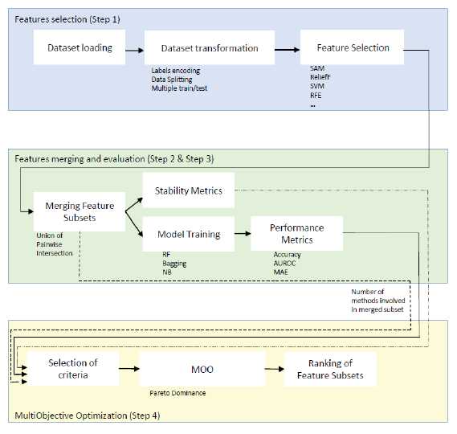

The steps for our proposed Pareto EFS are listed below. Each links to another page providing the code and results for each step.

**Step 1. Generate the various feature subsets using some pre-selected FS methods**

**Step 2. Aggregate the feature subsets resulting from the various FS methods using a selected merging strategy.**

**Step 3. Compute stability and performance metrics.**

**Step 4. Optimise the metrics obtained in (3) together with the number of feature methods using Pareto dominance and choose the subset of features ranking the highest. This feature subset will be the one giving the best stability while being most performing.**

**Step 5. Use of MOO on the 10 repeats of the top-ranked feature subset to select one final merged list.**

[output not shown]